# Homework 1

Ebru Gecici

19 11 2020

```r
library(data.table)
library(tidyverse)
library(dplyr)
data2020 = fread("E0.csv", select = c(2, 4:42))
data2019 = fread("E1.csv", select = c(2, 4:42))
data2018 = fread("E2.csv", select = 2:41)

GamesData = rbind(data2020, data2019, data2018)
```

In this homework, we examine the sports forecasting. Because sports forecasting is important factor in games. Many people, professionally (team managers, sponsors, the media and the growing number of punters) or unprofessionally (sports fans), are interested in sports forecasting. For this reason this forecasting has an important role to make predictions. In these studies, odd probability is also important because it gives more realistic results than probabilities. For this reason, in the sports forecasting, *odd probabilities* are preferred.

In the football games there are three probability:

1. **Home** team may win. (If the home team is win, we are called H)
2. The match may end in a **draw**. (If there is no team which win, we are called D)
3. **Away** team may win. (If the away team is win, we are called A)

After the basic explanation, we analyze this process in England Football League, i.e., *Premiere Leagure* by using 2018-2020 seasons.

## **Task 1**

### Histograms

Histograms gives basic idea of the data’s distribution. For this reason, we first examine the histogram of the number of goals. First we give number of goals scored by home team and then we give goals socred by away team. Lastly, the difference between number of goals of home team and number of goals away team is presented as histogram.

#### Number of Goals scored by Home Team

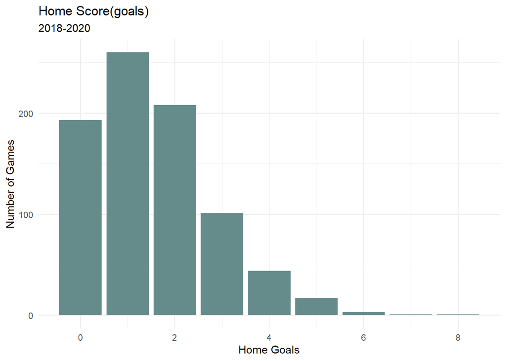

```r
# Home Score Goals
# Our data set name is GamesData
# Variable which we use to create is FTHG and its explanation is that number of goals scored by home team
GamesData %>%
  ggplot(., aes(x = FTHG)) +
  geom_histogram(stat = "count", fill = "paleturquoise4") +
  theme_minimal() +
  labs(x = "Home Goals",
       y = "Number of Games",
       title = "Home Score(goals)",
       subtitle = "2018-2020")
```

#### Number of Goals scored by Away Team

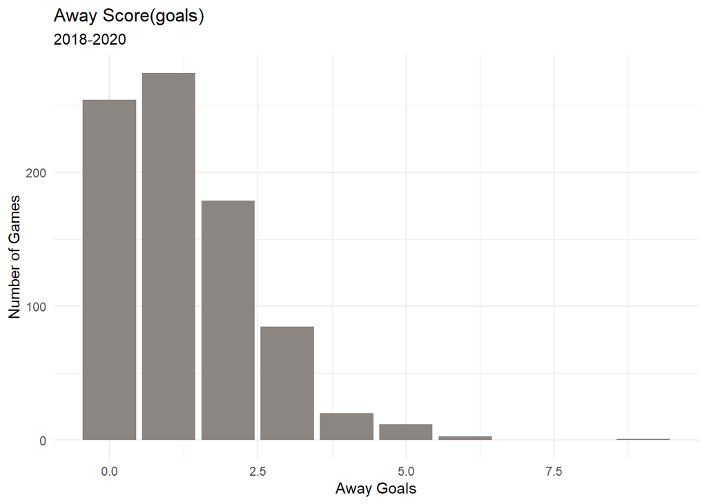

```r
# Away Score Goals
# Our data set name is GamesData
# Variable which we use to create is FTAG and its explanation is that number of goals scored by away team
GamesData %>%
  ggplot(., aes(x = FTAG)) +
  geom_histogram(stat = "count", fill = "seashell4") +
  theme_minimal() +
  labs(x = "Away Goals",
       y = "Number of Games",
       title = "Away Score(goals)",
       subtitle = "2018-2020")
```

#### Home Score(goals)– Away Score(goals)

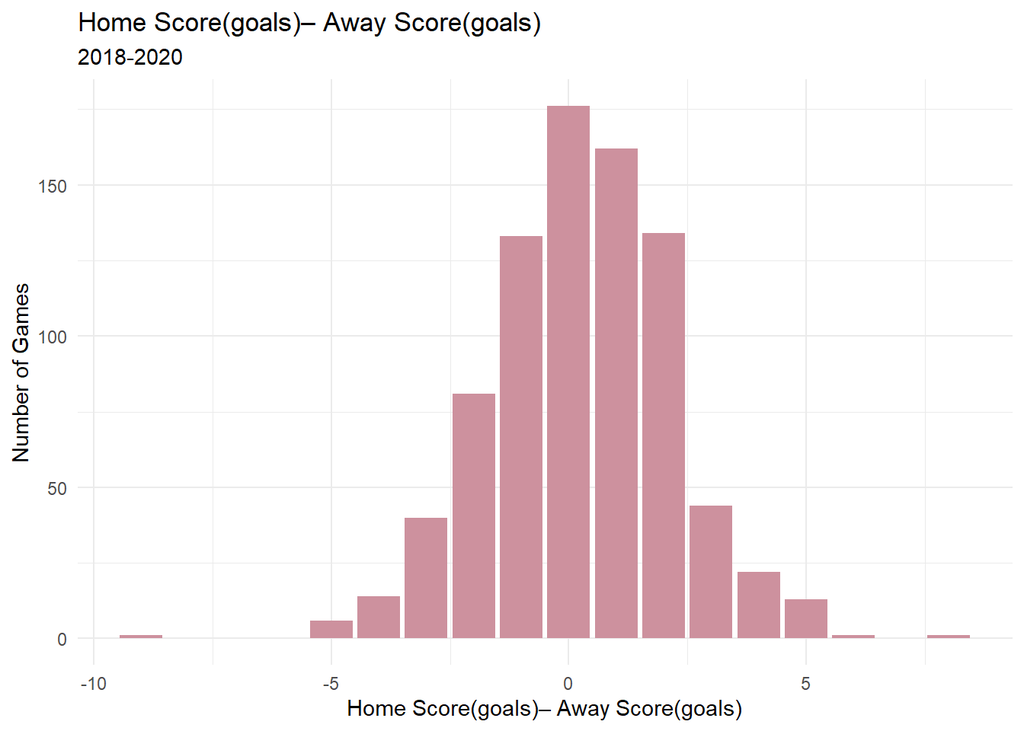

```r
# Difference between Home and Away
# Our data set name is GamesData
# Variable which we use to create is FTHG and its explanation is that number of goals scored by home team
GamesData %>%
  ggplot(., aes(x = FTHG-FTAG)) +
  geom_histogram(stat = "count", fill = "pink3") +
  theme_minimal() +
  labs(x = "Home Score(goals)– Away Score(goals)",
       y = "Number of Games",
       title = "Home Score(goals)– Away Score(goals)",
       subtitle = "2018-2020")
```

Home and away goal histograms are look like poisson distribution. But to represent more clearly we can add poisson distribution line into histograms.

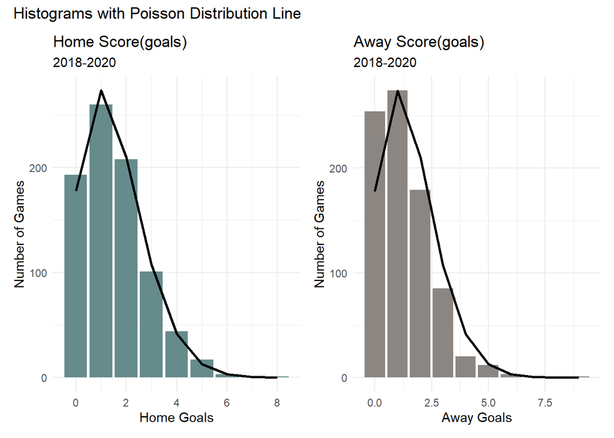

```r
library(patchwork)   # for combine plots in one lines


# First, we create data which follow poisson distribuiton. To make this data first we use Home goals
# Because we try to explain whether the home goals follow poisson distribution
Xh = seq(min(GamesData$FTHG), max(GamesData$FTHG), by = 1)
Yh = dpois(Xh, lambda = mean(GamesData$FTHG))
poisH = data.frame(Xh,Yh)

a =GamesData %>%
    ggplot() +
    geom_histogram(aes(x = FTHG), stat = "count", fill = "paleturquoise4") +
    geom_line(aes(x=Xh, y=Yh* nrow(GamesData)), data = poisH, color = "black", size =1) +
    theme_minimal() +
    labs(x = "Home Goals",
         y = "Number of Games",
         title = "Home Score(goals)",
         subtitle = "2018-2020")

# Like home goals, we make same processed for away goals
Xa = seq(min(GamesData$FTAG), max(GamesData$FTAG), by = 1)
Ya = dpois(Xa, lambda = mean(GamesData$FTHG))
poisA = data.frame(Xa,Ya)

b = GamesData %>%
    ggplot() +
    geom_histogram(aes(x = FTAG), stat = "count", fill = "seashell4") +
    geom_line(aes(x=Xa, y=Ya* nrow(GamesData)), data = poisA, color = "black", size =1) +
    theme_minimal() +
    labs(x = "Away Goals",
         y = "Number of Games",
         title = "Away Score(goals)",
         subtitle = "2018-2020")

(a | b) +
  plot_annotation(title = "Histograms with Poisson Distribution Line")
```

## **Task 2**

Task 2 is related to calculation of the odd and probabilities. These two features give an opportunity to estimate score of the match. For this reason, especially for bookmakers, these values are calculated and then according to the results, the unporfessional people and bookmakers bet on the match.

In this assignment, we try to define odd probability and match score estimation, and moreover to get probabilistic view, first we examine the data and then we calculate these probabilities. After that we obtain comparable about the given data set which belongs to `English Premier League` in between 2018 and 2020 seasons.

### Variable Names in the Data Set

```r
GamesData %>%
  colnames()
```

```
##  [1] "Date"     "HomeTeam" "AwayTeam" "FTHG"     "FTAG"     "FTR"
##  [7] "HTHG"     "HTAG"     "HTR"      "Referee"  "HS"       "AS"
## [13] "HST"      "AST"      "HF"       "AF"       "HC"       "AC"
## [19] "HY"       "AY"       "HR"       "AR"       "B365H"    "B365D"
## [25] "B365A"    "BWH"      "BWD"      "BWA"      "IWH"      "IWD"
## [31] "IWA"      "PSH"      "PSD"      "PSA"      "WHH"      "WHD"
## [37] "WHA"      "VCH"      "VCD"      "VCA"
```

We have different statistic value in this data set. This data set contains, home and away team information, red card information of the teams, odd probabilities, which is obtained from the each bet site, with home, away and draw results. Moreover, there are six different bet sites, which are *B365, BW, IW, PS, WH,* and *VC*. Each data contains three columns in the data for home, draw and away statistics. By using 4 of them, first I calculate the P(home win), P(tie) and P(away win) by P(x) = 1/odd.

I select **IW, PS, WH, VC** to calculate probabilities and compare the results.

### Calculation of the P(x) = 1/odd

P(x) = 1/odd process is implemented for each chosen bet site/bookmaker and obtained for home, away, and draw results.

```r
#Calculation of  probability
# IW bet
GamesData$IW_PH = 1 / GamesData$IWH # PH: probability home
GamesData$IW_PD = 1 / GamesData$IWD # PD: probability draw
GamesData$IW_PA = 1 / GamesData$IWA # PA: probability away

# PS bet
GamesData$PS_PH = 1 / GamesData$PSH # PH: probability home
GamesData$PS_PD = 1 / GamesData$PSD # PD: probability draw
GamesData$PS_PA = 1 / GamesData$PSA # PA: probability away

# WH bet
GamesData$WH_PH = 1 / GamesData$WHH # PH: probability home
GamesData$WH_PD = 1 / GamesData$WHD # PD: probability draw
GamesData$WH_PA = 1 / GamesData$WHA # PA: probability away

# VC bet
GamesData$VC_PH = 1 / GamesData$VCH # PH: probability home
GamesData$VC_PD = 1 / GamesData$VCD # PD: probability draw
GamesData$VC_PA = 1 / GamesData$VCA # PA: probability away
```

After the calculation process, new columns are added into the data set. To see difference, here the column names are given again. the variable names show that the last twelve variables are added after the probability calculation.

```r
# we add new columns by calculating probabilities with odd probability
GamesData %>%
  colnames()
```

```
##  [1] "Date"     "HomeTeam" "AwayTeam" "FTHG"     "FTAG"     "FTR"
##  [7] "HTHG"     "HTAG"     "HTR"      "Referee"  "HS"       "AS"
## [13] "HST"      "AST"      "HF"       "AF"       "HC"       "AC"
## [19] "HY"       "AY"       "HR"       "AR"       "B365H"    "B365D"
## [25] "B365A"    "BWH"      "BWD"      "BWA"      "IWH"      "IWD"
## [31] "IWA"      "PSH"      "PSD"      "PSA"      "WHH"      "WHD"
## [37] "WHA"      "VCH"      "VCD"      "VCA"      "IW_PH"    "IW_PD"
## [43] "IW_PA"    "PS_PH"    "PS_PD"    "PS_PA"    "WH_PH"    "WH_PD"
## [49] "WH_PA"    "VC_PH"    "VC_PD"    "VC_PA"
```

Then we calculate normalization for each probability to get more clear comparison of the values. In other words, the values can have different range, for this reason we need to rearrange.

```r
# Normalization of the Probabilities
# NPH: normalized home probability
# NPD: normalized draw probability
# NPA: normalized away probability
# Normalized IW bet
GamesData$IW_NPH = GamesData$IW_PH / (GamesData$IW_PH + GamesData$IW_PD + GamesData$IW_PA)
GamesData$IW_NPD = GamesData$IW_PD / (GamesData$IW_PH + GamesData$IW_PD + GamesData$IW_PA)
GamesData$IW_NPA = GamesData$IW_PA / (GamesData$IW_PH + GamesData$IW_PD + GamesData$IW_PA)

# Normalized PS bet
GamesData$PS_NPH = GamesData$PS_PH / (GamesData$PS_PH + GamesData$PS_PD + GamesData$PS_PA)
GamesData$PS_NPD = GamesData$PS_PD / (GamesData$PS_PH + GamesData$PS_PD + GamesData$PS_PA)
GamesData$PS_NPA = GamesData$PS_PA / (GamesData$PS_PH + GamesData$PS_PD + GamesData$PS_PA)

# Normalized WH bet
GamesData$WH_NPH = GamesData$WH_PH / (GamesData$WH_PH + GamesData$WH_PD + GamesData$WH_PA)
GamesData$WH_NPD = GamesData$WH_PD / (GamesData$WH_PH + GamesData$WH_PD + GamesData$WH_PA)
GamesData$WH_NPA = GamesData$WH_PA / (GamesData$WH_PH + GamesData$WH_PD + GamesData$WH_PA)

# Normalized VC bet
GamesData$VC_NPH = GamesData$VC_PH / (GamesData$VC_PH + GamesData$VC_PD + GamesData$VC_PA)
GamesData$VC_NPD = GamesData$VC_PD / (GamesData$VC_PH + GamesData$VC_PD + GamesData$VC_PA)
GamesData$VC_NPA = GamesData$VC_PA / (GamesData$VC_PH + GamesData$VC_PD + GamesData$VC_PA)
```

After that process, we have new 12 variables like the previous calculations.

```r
# we add new columns by calculating normalized probabilities with odd probability
GamesData %>%
  colnames()
```

```
##  [1] "Date"     "HomeTeam" "AwayTeam" "FTHG"     "FTAG"     "FTR"
##  [7] "HTHG"     "HTAG"     "HTR"      "Referee"  "HS"       "AS"
## [13] "HST"      "AST"      "HF"       "AF"       "HC"       "AC"
## [19] "HY"       "AY"       "HR"       "AR"       "B365H"    "B365D"
## [25] "B365A"    "BWH"      "BWD"      "BWA"      "IWH"      "IWD"
## [31] "IWA"      "PSH"      "PSD"      "PSA"      "WHH"      "WHD"
## [37] "WHA"      "VCH"      "VCD"      "VCA"      "IW_PH"    "IW_PD"
## [43] "IW_PA"    "PS_PH"    "PS_PD"    "PS_PA"    "WH_PH"    "WH_PD"
## [49] "WH_PA"    "VC_PH"    "VC_PD"    "VC_PA"    "IW_NPH"   "IW_NPD"
## [55] "IW_NPA"   "PS_NPH"   "PS_NPD"   "PS_NPA"   "WH_NPH"   "WH_NPD"
## [61] "WH_NPA"   "VC_NPH"   "VC_NPD"   "VC_NPA"
```

First construct a plot of P(home win) – P(away win) on x-axis and P (tie) on y-axis with first probability calculation; then plot the actual probabilities calculated using the results.

To calculate real probability, we use FTR variable, which is the full time result. Then we count the number of games into interval which we define.

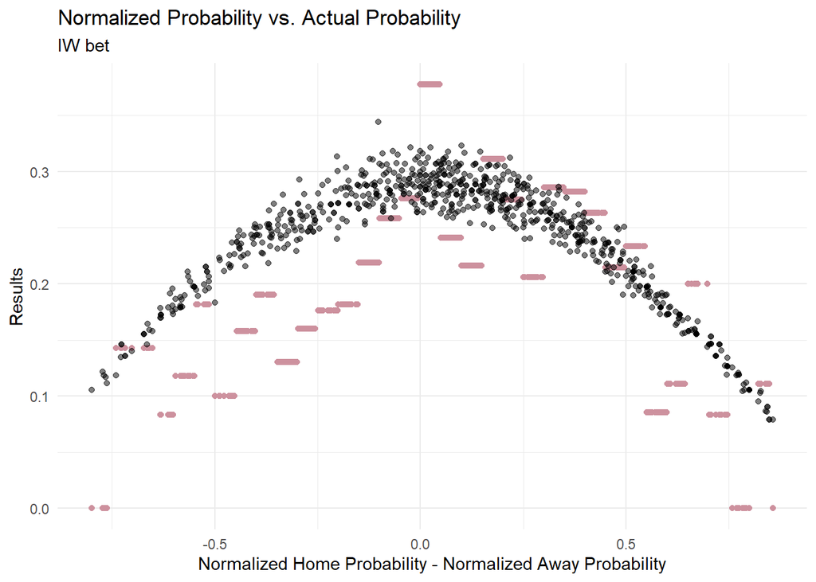

```r
#FTR
GamesData = GamesData %>%
  mutate(FTR_category = ifelse(FTR == 'D', 1, 0)) %>%
  mutate(Group = case_when(IW_NPH - IW_NPA < -0.95 ~ "1",
                           IW_NPH - IW_NPA < -0.9  ~ "2",
                           IW_NPH - IW_NPA < -0.85 ~ "3",
                           IW_NPH - IW_NPA < -0.8  ~ "4",
                           IW_NPH - IW_NPA < -0.75 ~ "5",
                           IW_NPH - IW_NPA < -0.7  ~ "6",
                           IW_NPH - IW_NPA < -0.65 ~ "7",
                           IW_NPH - IW_NPA < -0.6  ~ "8",
                           IW_NPH - IW_NPA < -0.55 ~ "9",
                           IW_NPH - IW_NPA < -0.5  ~ "10",
                           IW_NPH - IW_NPA < -0.45 ~ "11",
                           IW_NPH - IW_NPA < -0.4  ~ "12",
                           IW_NPH - IW_NPA < -0.35 ~ "13",
                           IW_NPH - IW_NPA < -0.3  ~ "14",
                           IW_NPH - IW_NPA < -0.25 ~ "15",
                           IW_NPH - IW_NPA < -0.2  ~ "16",
                           IW_NPH - IW_NPA < -0.15 ~ "17",
                           IW_NPH - IW_NPA < -0.1  ~ "18",
                           IW_NPH - IW_NPA < -0.05 ~ "19",
                           IW_NPH - IW_NPA <  0 ~ "20",
                           IW_NPH - IW_NPA <  0.05 ~ "21",
                           IW_NPH - IW_NPA <  0.1  ~ "22",
                           IW_NPH - IW_NPA <  0.15 ~ "23",
                           IW_NPH - IW_NPA <  0.2 ~ "24",
                           IW_NPH - IW_NPA <  0.25  ~ "25",
                           IW_NPH - IW_NPA <  0.3 ~ "26",
                           IW_NPH - IW_NPA <  0.35 ~ "27",
                           IW_NPH - IW_NPA <  0.4  ~ "28",
                           IW_NPH - IW_NPA <  0.45 ~ "29",
                           IW_NPH - IW_NPA <  0.5 ~ "30",
                           IW_NPH - IW_NPA <  0.55  ~ "31",
                           IW_NPH - IW_NPA <  0.6 ~ "32",
                           IW_NPH - IW_NPA <  0.65 ~ "33",
                           IW_NPH - IW_NPA <  0.7  ~ "34",
                           IW_NPH - IW_NPA <  0.75 ~ "35",
                           IW_NPH - IW_NPA <  0.8 ~ "36",
                           IW_NPH - IW_NPA <  0.85  ~ "37",
                           IW_NPH - IW_NPA <  0.9 ~ "38",
                           IW_NPH - IW_NPA <  0.95  ~ "39",
                           TRUE ~ "40")) %>%
  group_by(Group) %>%
  mutate(IWResult = mean(FTR_category))

#Graph
ggplot() +
  geom_point(aes(x = IW_NPH - IW_NPA, y = IWResult), data = GamesData, color = "pink3") +
  geom_point(aes(x = IW_NPH - IW_NPA, y = IW_NPD), data = GamesData, color = "black", alpha =0.5) +
  theme_minimal() +
  labs(title = "Normalized Probability vs. Actual Probability",
       subtitle = "IW bet",
       x = "Normalized Home Probability - Normalized Away Probability",
       y = "Results")
```

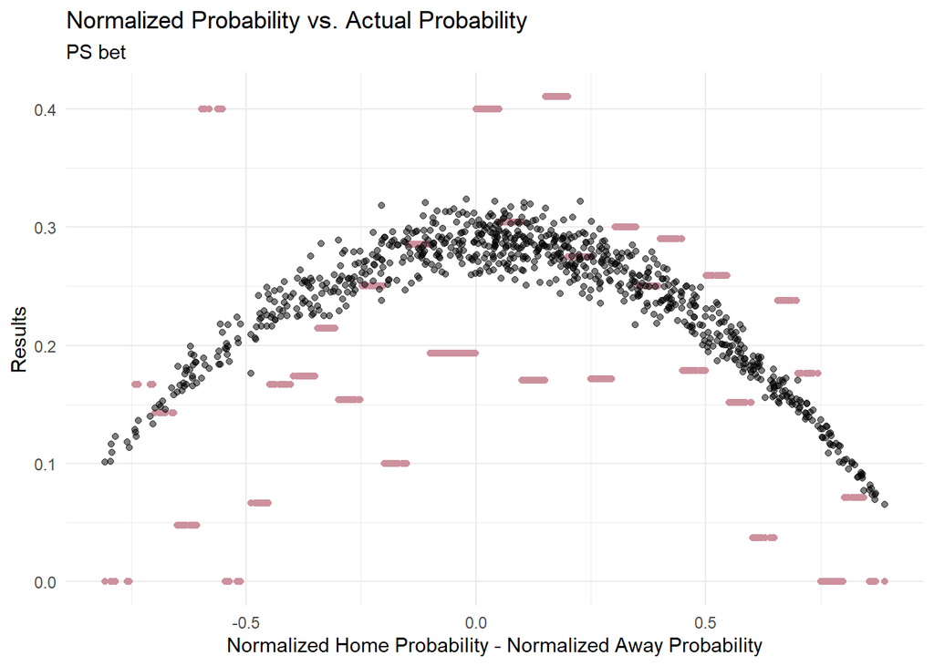

```r
# FTR
GamesData = GamesData %>%
  mutate(FTR_category = ifelse(FTR == 'D', 1, 0)) %>%
  mutate(Group = case_when(PS_NPH - PS_NPA < -0.95 ~ "1",
                           PS_NPH - PS_NPA < -0.9  ~ "2",
                           PS_NPH - PS_NPA < -0.85 ~ "3",
                           PS_NPH - PS_NPA < -0.8  ~ "4",
                           PS_NPH - PS_NPA < -0.75 ~ "5",
                           PS_NPH - PS_NPA < -0.7  ~ "6",
                           PS_NPH - PS_NPA < -0.65 ~ "7",
                           PS_NPH - PS_NPA < -0.6  ~ "8",
                           PS_NPH - PS_NPA < -0.55 ~ "9",
                           PS_NPH - PS_NPA < -0.5  ~ "10",
                           PS_NPH - PS_NPA < -0.45 ~ "11",
                           PS_NPH - PS_NPA < -0.4  ~ "12",
                           PS_NPH - PS_NPA < -0.35 ~ "13",
                           PS_NPH - PS_NPA < -0.3  ~ "14",
                           PS_NPH - PS_NPA < -0.25 ~ "15",
                           PS_NPH - PS_NPA < -0.2  ~ "16",
                           PS_NPH - PS_NPA < -0.15 ~ "17",
                           PS_NPH - PS_NPA < -0.1  ~ "18",
                           PS_NPH - PS_NPA < -0.05 ~ "19",
                           PS_NPH - PS_NPA <  0 ~ "20",
                           PS_NPH - PS_NPA <  0.05 ~ "21",
                           PS_NPH - PS_NPA <  0.1  ~ "22",
                           PS_NPH - PS_NPA <  0.15 ~ "23",
                           PS_NPH - PS_NPA <  0.2 ~ "24",
                           PS_NPH - PS_NPA <  0.25  ~ "25",
                           PS_NPH - PS_NPA <  0.3 ~ "26",
                           PS_NPH - PS_NPA <  0.35 ~ "27",
                           PS_NPH - PS_NPA <  0.4  ~ "28",
                           PS_NPH - PS_NPA <  0.45 ~ "29",
                           PS_NPH - PS_NPA <  0.5 ~ "30",
                           PS_NPH - PS_NPA <  0.55  ~ "31",
                           PS_NPH - PS_NPA <  0.6 ~ "32",
                           PS_NPH - PS_NPA <  0.65 ~ "33",
                           PS_NPH - PS_NPA <  0.7  ~ "34",
                           PS_NPH - PS_NPA <  0.75 ~ "35",
                           PS_NPH - PS_NPA <  0.8 ~ "36",
                           PS_NPH - PS_NPA <  0.85  ~ "37",
                           PS_NPH - PS_NPA <  0.9 ~ "38",
                           PS_NPH - PS_NPA <  0.95  ~ "39",
                           TRUE ~ "40")) %>%
  group_by(Group) %>%
  mutate(PSResult = mean(FTR_category))

#Graph
ggplot() +
  geom_point(aes(x = PS_NPH - PS_NPA, y = PSResult), data = GamesData, color = "pink3") +
  geom_point(aes(x = PS_NPH - PS_NPA, y = PS_NPD), data = GamesData, color = "black", alpha =0.5) +
  theme_minimal() +
  labs(title = "Normalized Probability vs. Actual Probability",
       subtitle = "PS bet",
       x = "Normalized Home Probability - Normalized Away Probability",
       y = "Results")
```

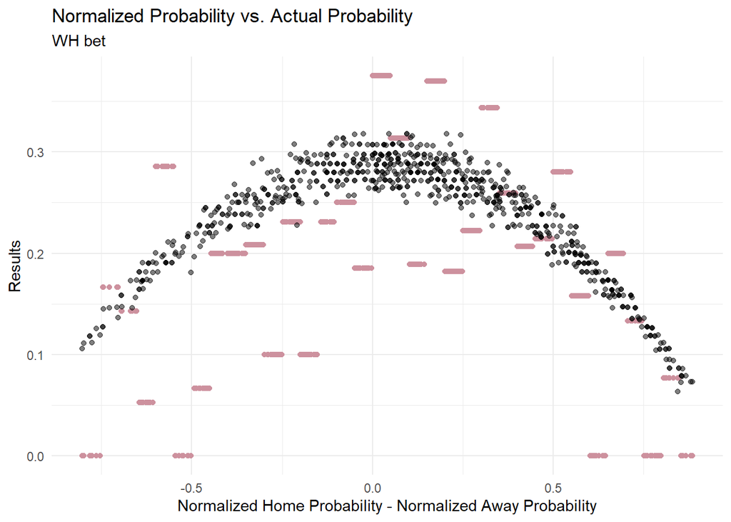

```r
#FTR
GamesData = GamesData %>%
  mutate(FTR_category = ifelse(FTR == 'D', 1, 0)) %>%
  mutate(Group = case_when(WH_NPH - WH_NPA < -0.95 ~ "1",
                           WH_NPH - WH_NPA < -0.9  ~ "2",
                           WH_NPH - WH_NPA < -0.85 ~ "3",
                           WH_NPH - WH_NPA < -0.8  ~ "4",
                           WH_NPH - WH_NPA < -0.75 ~ "5",
                           WH_NPH - WH_NPA < -0.7  ~ "6",
                           WH_NPH - WH_NPA < -0.65 ~ "7",
                           WH_NPH - WH_NPA < -0.6  ~ "8",
                           WH_NPH - WH_NPA < -0.55 ~ "9",
                           WH_NPH - WH_NPA < -0.5  ~ "10",
                           WH_NPH - WH_NPA < -0.45 ~ "11",
                           WH_NPH - WH_NPA < -0.4  ~ "12",
                           WH_NPH - WH_NPA < -0.35 ~ "13",
                           WH_NPH - WH_NPA < -0.3  ~ "14",
                           WH_NPH - WH_NPA < -0.25 ~ "15",
                           WH_NPH - WH_NPA < -0.2  ~ "16",
                           WH_NPH - WH_NPA < -0.15 ~ "17",
                           WH_NPH - WH_NPA < -0.1  ~ "18",
                           WH_NPH - WH_NPA < -0.05 ~ "19",
                           WH_NPH - WH_NPA <  0 ~ "20",
                           WH_NPH - WH_NPA <  0.05 ~ "21",
                           WH_NPH - WH_NPA <  0.1  ~ "22",
                           WH_NPH - WH_NPA <  0.15 ~ "23",
                           WH_NPH - WH_NPA <  0.2 ~ "24",
                           WH_NPH - WH_NPA <  0.25  ~ "25",
                           WH_NPH - WH_NPA <  0.3 ~ "26",
                           WH_NPH - WH_NPA <  0.35 ~ "27",
                           WH_NPH - WH_NPA <  0.4  ~ "28",
                           WH_NPH - WH_NPA <  0.45 ~ "29",
                           WH_NPH - WH_NPA <  0.5 ~ "30",
                           WH_NPH - WH_NPA <  0.55  ~ "31",
                           WH_NPH - WH_NPA <  0.6 ~ "32",
                           WH_NPH - WH_NPA <  0.65 ~ "33",
                           WH_NPH - WH_NPA <  0.7  ~ "34",
                           WH_NPH - WH_NPA <  0.75 ~ "35",
                           WH_NPH - WH_NPA <  0.8 ~ "36",
                           WH_NPH - WH_NPA <  0.85  ~ "37",
                           WH_NPH - WH_NPA <  0.9 ~ "38",
                           WH_NPH - WH_NPA <  0.95  ~ "39",
                           TRUE ~ "40")) %>%
  group_by(Group) %>%
  mutate(WHResult = mean(FTR_category))

#Graph
ggplot() +
  geom_point(aes(x = WH_NPH - WH_NPA, y = WHResult), data = GamesData, color = "pink3") +
  geom_point(aes(x = WH_NPH - WH_NPA, y = WH_NPD), data = GamesData, color = "black", alpha =0.5) +
  theme_minimal() +
  labs(title = "Normalized Probability vs. Actual Probability",
       subtitle = "WH bet",
       x = "Normalized Home Probability - Normalized Away Probability",
       y = "Results")
```

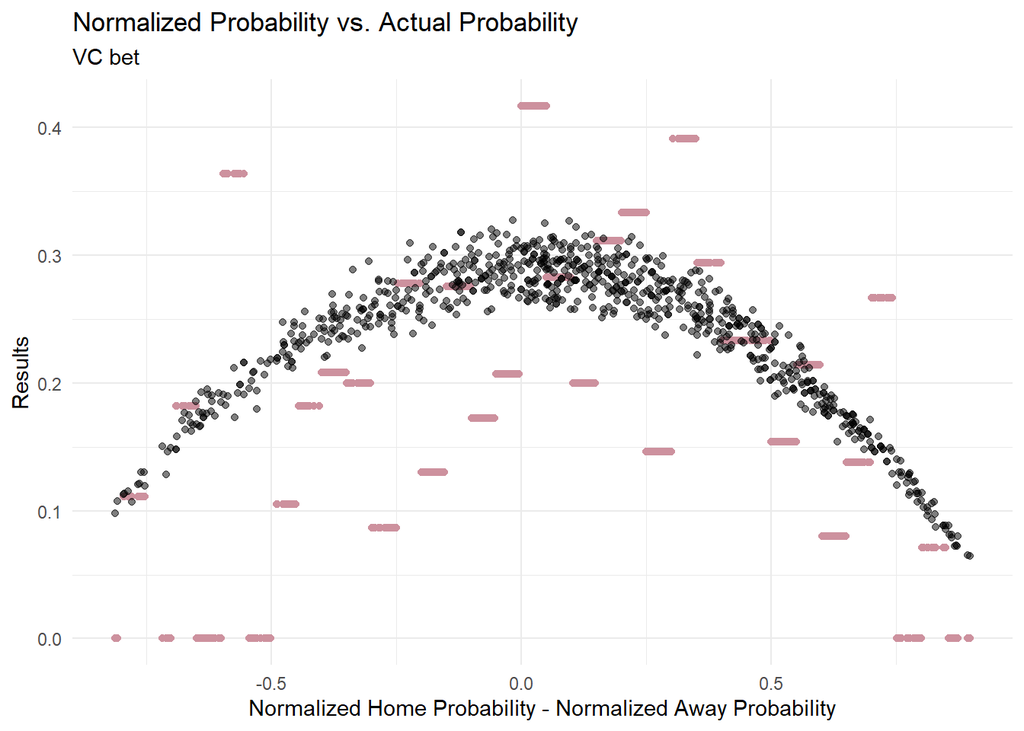

```r
#FTR
GamesData = GamesData %>%
  mutate(FTR_category = ifelse(FTR == 'D', 1, 0)) %>%
  mutate(Group = case_when(VC_NPH - VC_NPA < -0.95 ~ "1",
                           VC_NPH - VC_NPA < -0.9  ~ "2",
                           VC_NPH - VC_NPA < -0.85 ~ "3",
                           VC_NPH - VC_NPA < -0.8  ~ "4",
                           VC_NPH - VC_NPA < -0.75 ~ "5",
                           VC_NPH - VC_NPA < -0.7  ~ "6",
                           VC_NPH - VC_NPA < -0.65 ~ "7",
                           VC_NPH - VC_NPA < -0.6  ~ "8",
                           VC_NPH - VC_NPA < -0.55 ~ "9",
                           VC_NPH - VC_NPA < -0.5  ~ "10",
                           VC_NPH - VC_NPA < -0.45 ~ "11",
                           VC_NPH - VC_NPA < -0.4  ~ "12",
                           VC_NPH - VC_NPA < -0.35 ~ "13",
                           VC_NPH - VC_NPA < -0.3  ~ "14",
                           VC_NPH - VC_NPA < -0.25 ~ "15",
                           VC_NPH - VC_NPA < -0.2  ~ "16",
                           VC_NPH - VC_NPA < -0.15 ~ "17",
                           VC_NPH - VC_NPA < -0.1  ~ "18",
                           VC_NPH - VC_NPA < -0.05 ~ "19",
                           VC_NPH - VC_NPA <  0 ~ "20",
                           VC_NPH - VC_NPA <  0.05 ~ "21",
                           VC_NPH - VC_NPA <  0.1  ~ "22",
                           VC_NPH - VC_NPA <  0.15 ~ "23",
                           VC_NPH - VC_NPA <  0.2 ~ "24",
                           VC_NPH - VC_NPA <  0.25  ~ "25",
                           VC_NPH - VC_NPA <  0.3 ~ "26",
                           VC_NPH - VC_NPA <  0.35 ~ "27",
                           VC_NPH - VC_NPA <  0.4  ~ "28",
                           VC_NPH - VC_NPA <  0.45 ~ "29",
                           VC_NPH - VC_NPA <  0.5 ~ "30",
                           VC_NPH - VC_NPA <  0.55  ~ "31",
                           VC_NPH - VC_NPA <  0.6 ~ "32",
                           VC_NPH - VC_NPA <  0.65 ~ "33",
                           VC_NPH - VC_NPA <  0.7  ~ "34",
                           VC_NPH - VC_NPA <  0.75 ~ "35",
                           VC_NPH - VC_NPA <  0.8 ~ "36",
                           VC_NPH - VC_NPA <  0.85  ~ "37",
                           VC_NPH - VC_NPA <  0.9 ~ "38",
                           VC_NPH - VC_NPA <  0.95  ~ "39",
                           TRUE ~ "40")) %>%
  group_by(Group) %>%
  mutate(VCResult = mean(FTR_category))

#Graph
ggplot() +
  geom_point(aes(x = VC_NPH - VC_NPA, y = VCResult), data = GamesData, color = "pink3") +
  geom_point(aes(x = VC_NPH - VC_NPA, y = VC_NPD), data = GamesData, color = "black", alpha =0.5) +
  theme_minimal() +
  labs(title = "Normalized Probability vs. Actual Probability",
       subtitle = "VC bet",
       x = "Normalized Home Probability - Normalized Away Probability",
       y = "Results")
```

## **Task 3**

Sometimes the red card can be affect the result of the games and this affect also affect match probabilities. For this reason, to get this problem from the calculation, we can make previous calculations without red card data.

HR (home red card) and AR (away red card) are 0, that is the both of them do not have player with red card, we can use this data. For this reason we create a new data without red card.

```r
GamesDataRed = GamesData %>%
                  filter(HR == 0 & AR == 0)
```

Now to calculate actual data, we can use new calculated data set.

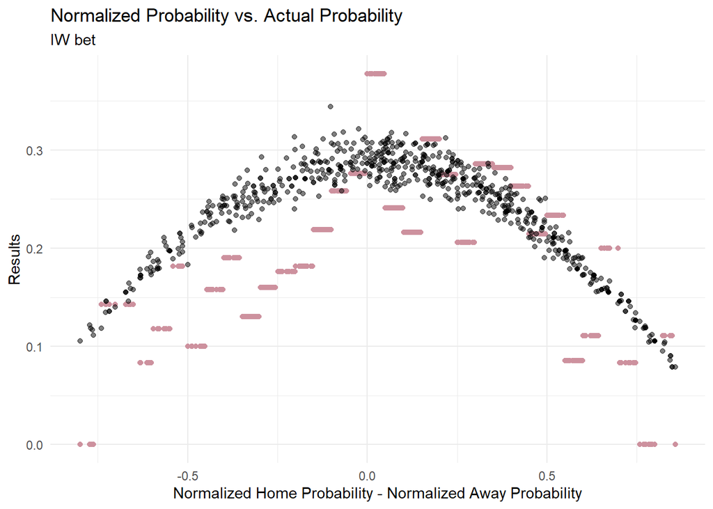

```r
#FTR
GamesData = GamesData %>%
  mutate(FTR_category = ifelse(FTR == 'D', 1, 0)) %>%
  mutate(Group = case_when(IW_NPH - IW_NPA < -0.95 ~ "1",
                           IW_NPH - IW_NPA < -0.9  ~ "2",
                           IW_NPH - IW_NPA < -0.85 ~ "3",
                           IW_NPH - IW_NPA < -0.8  ~ "4",
                           IW_NPH - IW_NPA < -0.75 ~ "5",
                           IW_NPH - IW_NPA < -0.7  ~ "6",
                           IW_NPH - IW_NPA < -0.65 ~ "7",
                           IW_NPH - IW_NPA < -0.6  ~ "8",
                           IW_NPH - IW_NPA < -0.55 ~ "9",
                           IW_NPH - IW_NPA < -0.5  ~ "10",
                           IW_NPH - IW_NPA < -0.45 ~ "11",
                           IW_NPH - IW_NPA < -0.4  ~ "12",
                           IW_NPH - IW_NPA < -0.35 ~ "13",
                           IW_NPH - IW_NPA < -0.3  ~ "14",
                           IW_NPH - IW_NPA < -0.25 ~ "15",
                           IW_NPH - IW_NPA < -0.2  ~ "16",
                           IW_NPH - IW_NPA < -0.15 ~ "17",
                           IW_NPH - IW_NPA < -0.1  ~ "18",
                           IW_NPH - IW_NPA < -0.05 ~ "19",
                           IW_NPH - IW_NPA <  0 ~ "20",
                           IW_NPH - IW_NPA <  0.05 ~ "21",
                           IW_NPH - IW_NPA <  0.1  ~ "22",
                           IW_NPH - IW_NPA <  0.15 ~ "23",
                           IW_NPH - IW_NPA <  0.2 ~ "24",
                           IW_NPH - IW_NPA <  0.25  ~ "25",
                           IW_NPH - IW_NPA <  0.3 ~ "26",
                           IW_NPH - IW_NPA <  0.35 ~ "27",
                           IW_NPH - IW_NPA <  0.4  ~ "28",
                           IW_NPH - IW_NPA <  0.45 ~ "29",
                           IW_NPH - IW_NPA <  0.5 ~ "30",
                           IW_NPH - IW_NPA <  0.55  ~ "31",
                           IW_NPH - IW_NPA <  0.6 ~ "32",
                           IW_NPH - IW_NPA <  0.65 ~ "33",
                           IW_NPH - IW_NPA <  0.7  ~ "34",
                           IW_NPH - IW_NPA <  0.75 ~ "35",
                           IW_NPH - IW_NPA <  0.8 ~ "36",
                           IW_NPH - IW_NPA <  0.85  ~ "37",
                           IW_NPH - IW_NPA <  0.9 ~ "38",
                           IW_NPH - IW_NPA <  0.95  ~ "39",
                           TRUE ~ "40")) %>%
  group_by(Group) %>%
  mutate(IWResult = mean(FTR_category))

#Graph
ggplot() +
  geom_point(aes(x = IW_NPH - IW_NPA, y = IWResult), data = GamesDataRed, color = "pink3") +
  geom_point(aes(x = IW_NPH - IW_NPA, y = IW_NPD), data = GamesDataRed, color = "black", alpha =0.5) +
  theme_minimal() +
  labs(title = "Normalized Probability vs. Actual Probability",
       subtitle = "IW bet",
       x = "Normalized Home Probability - Normalized Away Probability",
       y = "Results")
```

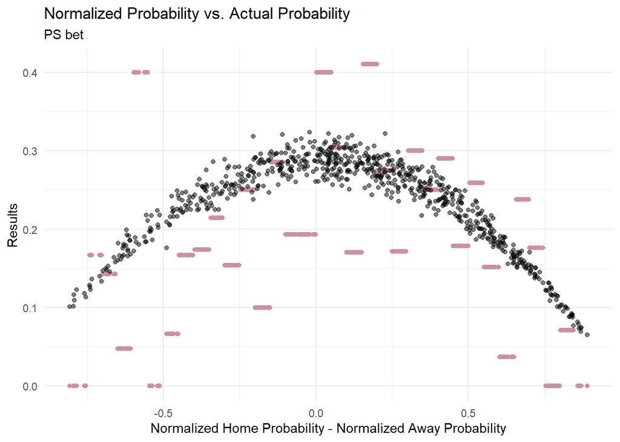

```r
#FTR
GamesData = GamesData %>%
  mutate(FTR_category = ifelse(FTR == 'D', 1, 0)) %>%
  mutate(Group = case_when(PS_NPH - PS_NPA < -0.95 ~ "1",
                           PS_NPH - PS_NPA < -0.9  ~ "2",
                           PS_NPH - PS_NPA < -0.85 ~ "3",
                           PS_NPH - PS_NPA < -0.8  ~ "4",
                           PS_NPH - PS_NPA < -0.75 ~ "5",
                           PS_NPH - PS_NPA < -0.7  ~ "6",
                           PS_NPH - PS_NPA < -0.65 ~ "7",
                           PS_NPH - PS_NPA < -0.6  ~ "8",
                           PS_NPH - PS_NPA < -0.55 ~ "9",
                           PS_NPH - PS_NPA < -0.5  ~ "10",
                           PS_NPH - PS_NPA < -0.45 ~ "11",
                           PS_NPH - PS_NPA < -0.4  ~ "12",
                           PS_NPH - PS_NPA < -0.35 ~ "13",
                           PS_NPH - PS_NPA < -0.3  ~ "14",
                           PS_NPH - PS_NPA < -0.25 ~ "15",
                           PS_NPH - PS_NPA < -0.2  ~ "16",
                           PS_NPH - PS_NPA < -0.15 ~ "17",
                           PS_NPH - PS_NPA < -0.1  ~ "18",
                           PS_NPH - PS_NPA < -0.05 ~ "19",
                           PS_NPH - PS_NPA <  0 ~ "20",
                           PS_NPH - PS_NPA <  0.05 ~ "21",
                           PS_NPH - PS_NPA <  0.1  ~ "22",
                           PS_NPH - PS_NPA <  0.15 ~ "23",
                           PS_NPH - PS_NPA <  0.2 ~ "24",
                           PS_NPH - PS_NPA <  0.25  ~ "25",
                           PS_NPH - PS_NPA <  0.3 ~ "26",
                           PS_NPH - PS_NPA <  0.35 ~ "27",
                           PS_NPH - PS_NPA <  0.4  ~ "28",
                           PS_NPH - PS_NPA <  0.45 ~ "29",
                           PS_NPH - PS_NPA <  0.5 ~ "30",
                           PS_NPH - PS_NPA <  0.55  ~ "31",
                           PS_NPH - PS_NPA <  0.6 ~ "32",
                           PS_NPH - PS_NPA <  0.65 ~ "33",
                           PS_NPH - PS_NPA <  0.7  ~ "34",
                           PS_NPH - PS_NPA <  0.75 ~ "35",
                           PS_NPH - PS_NPA <  0.8 ~ "36",
                           PS_NPH - PS_NPA <  0.85  ~ "37",
                           PS_NPH - PS_NPA <  0.9 ~ "38",
                           PS_NPH - PS_NPA <  0.95  ~ "39",
                           TRUE ~ "40")) %>%
  group_by(Group) %>%
  mutate(PSResult = mean(FTR_category))

#Graph
ggplot() +
  geom_point(aes(x = PS_NPH - PS_NPA, y = PSResult), data = GamesDataRed, color = "pink3") +
  geom_point(aes(x = PS_NPH - PS_NPA, y = PS_NPD), data = GamesDataRed, color = "black", alpha =0.5) +
  theme_minimal() +
  labs(title = "Normalized Probability vs. Actual Probability",
       subtitle = "PS bet",
       x = "Normalized Home Probability - Normalized Away Probability",
       y = "Results")
```

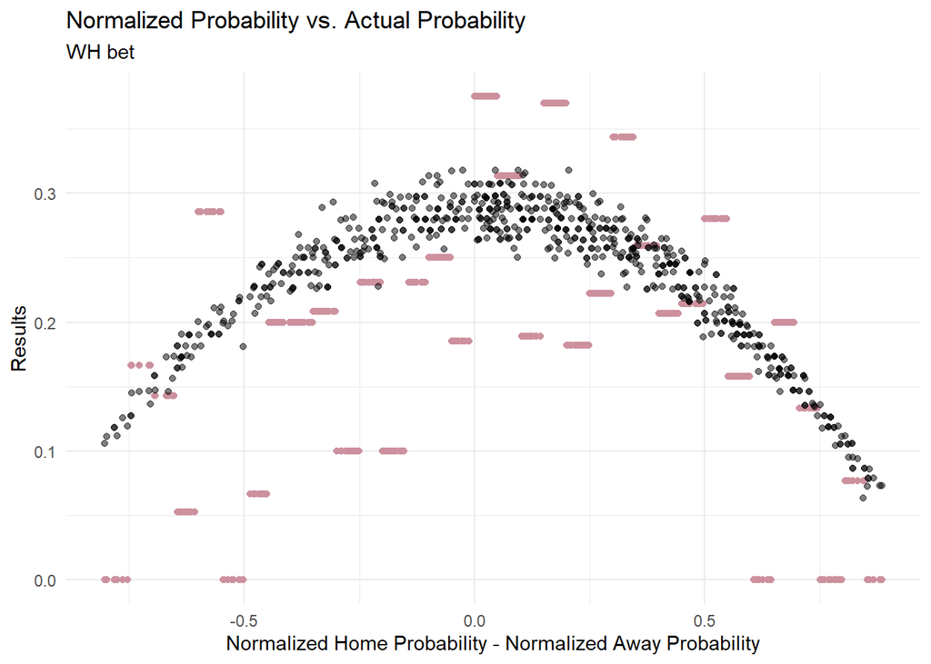

```r
#FTR
GamesData = GamesData %>%
  mutate(FTR_category = ifelse(FTR == 'D', 1, 0)) %>%
  mutate(Group = case_when(WH_NPH - WH_NPA < -0.95 ~ "1",
                           WH_NPH - WH_NPA < -0.9  ~ "2",
                           WH_NPH - WH_NPA < -0.85 ~ "3",
                           WH_NPH - WH_NPA < -0.8  ~ "4",
                           WH_NPH - WH_NPA < -0.75 ~ "5",
                           WH_NPH - WH_NPA < -0.7  ~ "6",
                           WH_NPH - WH_NPA < -0.65 ~ "7",
                           WH_NPH - WH_NPA < -0.6  ~ "8",
                           WH_NPH - WH_NPA < -0.55 ~ "9",
                           WH_NPH - WH_NPA < -0.5  ~ "10",
                           WH_NPH - WH_NPA < -0.45 ~ "11",
                           WH_NPH - WH_NPA < -0.4  ~ "12",
                           WH_NPH - WH_NPA < -0.35 ~ "13",
                           WH_NPH - WH_NPA < -0.3  ~ "14",
                           WH_NPH - WH_NPA < -0.25 ~ "15",
                           WH_NPH - WH_NPA < -0.2  ~ "16",
                           WH_NPH - WH_NPA < -0.15 ~ "17",
                           WH_NPH - WH_NPA < -0.1  ~ "18",
                           WH_NPH - WH_NPA < -0.05 ~ "19",
                           WH_NPH - WH_NPA <  0 ~ "20",
                           WH_NPH - WH_NPA <  0.05 ~ "21",
                           WH_NPH - WH_NPA <  0.1  ~ "22",
                           WH_NPH - WH_NPA <  0.15 ~ "23",
                           WH_NPH - WH_NPA <  0.2 ~ "24",
                           WH_NPH - WH_NPA <  0.25  ~ "25",
                           WH_NPH - WH_NPA <  0.3 ~ "26",
                           WH_NPH - WH_NPA <  0.35 ~ "27",
                           WH_NPH - WH_NPA <  0.4  ~ "28",
                           WH_NPH - WH_NPA <  0.45 ~ "29",
                           WH_NPH - WH_NPA <  0.5 ~ "30",
                           WH_NPH - WH_NPA <  0.55  ~ "31",
                           WH_NPH - WH_NPA <  0.6 ~ "32",
                           WH_NPH - WH_NPA <  0.65 ~ "33",
                           WH_NPH - WH_NPA <  0.7  ~ "34",
                           WH_NPH - WH_NPA <  0.75 ~ "35",
                           WH_NPH - WH_NPA <  0.8 ~ "36",
                           WH_NPH - WH_NPA <  0.85  ~ "37",
                           WH_NPH - WH_NPA <  0.9 ~ "38",
                           WH_NPH - WH_NPA <  0.95  ~ "39",
                           TRUE ~ "40")) %>%
  group_by(Group) %>%
  mutate(WHResult = mean(FTR_category))

#Graph
ggplot() +
  geom_point(aes(x = WH_NPH - WH_NPA, y = WHResult), data = GamesDataRed, color = "pink3") +
  geom_point(aes(x = WH_NPH - WH_NPA, y = WH_NPD), data = GamesDataRed, color = "black", alpha =0.5) +
  theme_minimal() +
  labs(title = "Normalized Probability vs. Actual Probability",
       subtitle = "WH bet",
       x = "Normalized Home Probability - Normalized Away Probability",
       y = "Results")
```

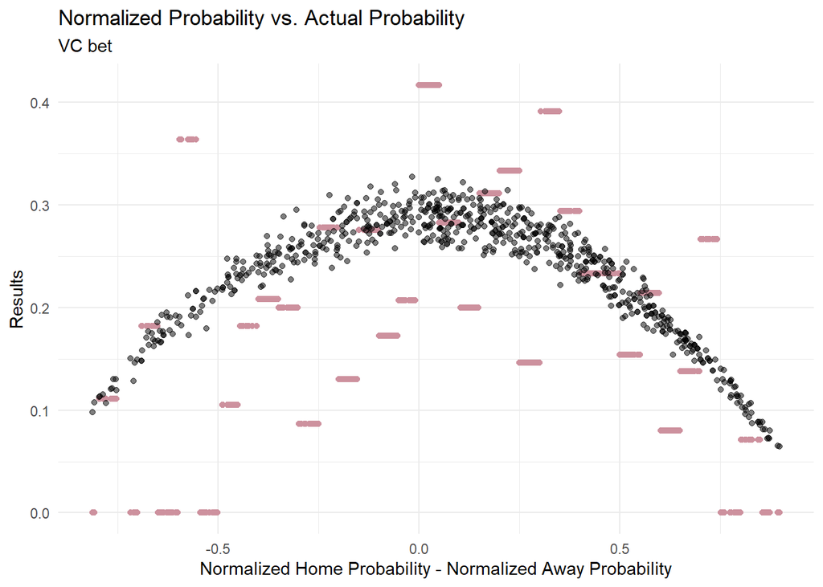

```r
#FTR
GamesData = GamesData %>%
  mutate(FTR_category = ifelse(FTR == 'D', 1, 0)) %>%
  mutate(Group = case_when(VC_NPH - VC_NPA < -0.95 ~ "1",
                           VC_NPH - VC_NPA < -0.9  ~ "2",
                           VC_NPH - VC_NPA < -0.85 ~ "3",
                           VC_NPH - VC_NPA < -0.8  ~ "4",
                           VC_NPH - VC_NPA < -0.75 ~ "5",
                           VC_NPH - VC_NPA < -0.7  ~ "6",
                           VC_NPH - VC_NPA < -0.65 ~ "7",
                           VC_NPH - VC_NPA < -0.6  ~ "8",
                           VC_NPH - VC_NPA < -0.55 ~ "9",
                           VC_NPH - VC_NPA < -0.5  ~ "10",
                           VC_NPH - VC_NPA < -0.45 ~ "11",
                           VC_NPH - VC_NPA < -0.4  ~ "12",
                           VC_NPH - VC_NPA < -0.35 ~ "13",
                           VC_NPH - VC_NPA < -0.3  ~ "14",
                           VC_NPH - VC_NPA < -0.25 ~ "15",
                           VC_NPH - VC_NPA < -0.2  ~ "16",
                           VC_NPH - VC_NPA < -0.15 ~ "17",
                           VC_NPH - VC_NPA < -0.1  ~ "18",
                           VC_NPH - VC_NPA < -0.05 ~ "19",
                           VC_NPH - VC_NPA <  0 ~ "20",
                           VC_NPH - VC_NPA <  0.05 ~ "21",
                           VC_NPH - VC_NPA <  0.1  ~ "22",
                           VC_NPH - VC_NPA <  0.15 ~ "23",
                           VC_NPH - VC_NPA <  0.2 ~ "24",
                           VC_NPH - VC_NPA <  0.25  ~ "25",
                           VC_NPH - VC_NPA <  0.3 ~ "26",
                           VC_NPH - VC_NPA <  0.35 ~ "27",
                           VC_NPH - VC_NPA <  0.4  ~ "28",
                           VC_NPH - VC_NPA <  0.45 ~ "29",
                           VC_NPH - VC_NPA <  0.5 ~ "30",
                           VC_NPH - VC_NPA <  0.55  ~ "31",
                           VC_NPH - VC_NPA <  0.6 ~ "32",
                           VC_NPH - VC_NPA <  0.65 ~ "33",
                           VC_NPH - VC_NPA <  0.7  ~ "34",
                           VC_NPH - VC_NPA <  0.75 ~ "35",
                           VC_NPH - VC_NPA <  0.8 ~ "36",
                           VC_NPH - VC_NPA <  0.85  ~ "37",
                           VC_NPH - VC_NPA <  0.9 ~ "38",
                           VC_NPH - VC_NPA <  0.95  ~ "39",
                           TRUE ~ "40")) %>%
  group_by(Group) %>%
  mutate(VCResult = mean(FTR_category))

#Graph
ggplot() +
  geom_point(aes(x = VC_NPH - VC_NPA, y = VCResult), data = GamesDataRed, color = "pink3") +
  geom_point(aes(x = VC_NPH - VC_NPA, y = VC_NPD), data = GamesDataRed, color = "black", alpha =0.5) +
  theme_minimal() +
  labs(title = "Normalized Probability vs. Actual Probability",
       subtitle = "VC bet",
       x = "Normalized Home Probability - Normalized Away Probability",
       y = "Results")
```

### Interpretaion of Task 2 and Task 3

To give detail of the interpretation, I want to show graph together.

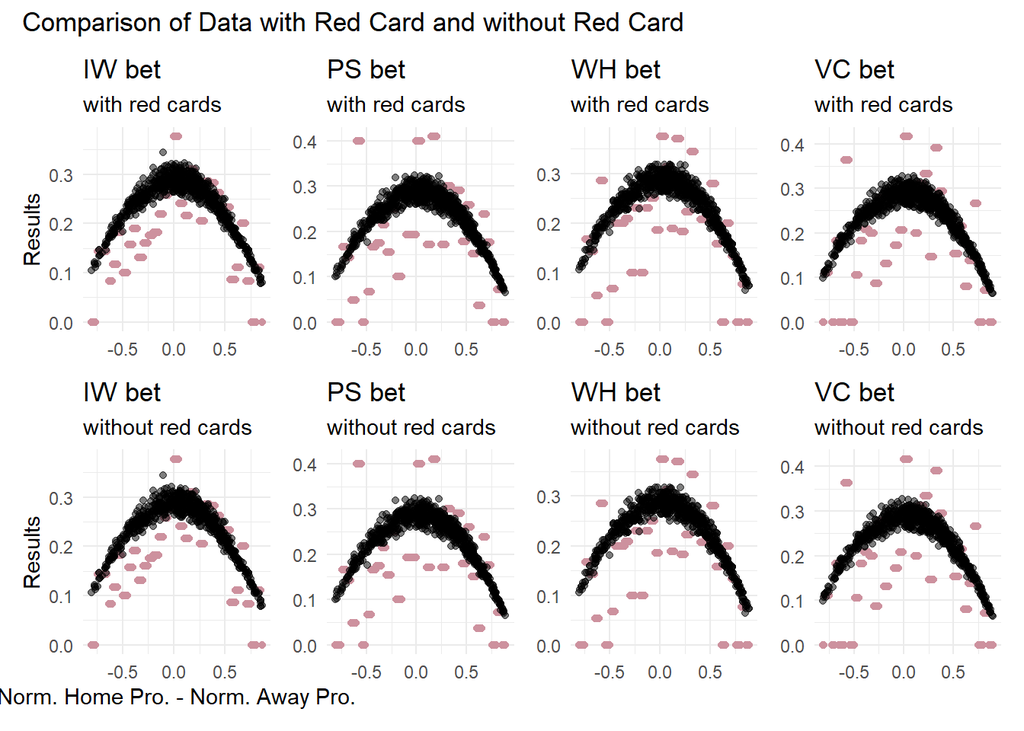

```r
A = ggplot() +
  geom_point(aes(x = IW_NPH - IW_NPA, y = IWResult), data = GamesData, color = "pink3") +
  geom_point(aes(x = IW_NPH - IW_NPA, y = IW_NPD), data = GamesData, color = "black", alpha =0.5) +
  theme_minimal() +
  theme(axis.title.x = element_blank()) +
  labs(title = "IW bet",
       subtitle = "with red cards",
       y = "Results")

B = ggplot() +
  geom_point(aes(x = PS_NPH - PS_NPA, y = PSResult), data = GamesData, color = "pink3") +
  geom_point(aes(x = PS_NPH - PS_NPA, y = PS_NPD), data = GamesData, color = "black", alpha =0.5) +
  theme_minimal() +
  theme(axis.title.x = element_blank(), axis.title.y = element_blank()) +
  labs(title = "PS bet",
       subtitle = "with red cards")


C = ggplot() +
  geom_point(aes(x = WH_NPH - WH_NPA, y = WHResult), data = GamesData, color = "pink3") +
  geom_point(aes(x = WH_NPH - WH_NPA, y = WH_NPD), data = GamesData, color = "black", alpha =0.5) +
  theme_minimal() +
  theme(axis.title.x = element_blank(), axis.title.y = element_blank()) +
  labs(title = "WH bet",
       subtitle = "with red cards")


D = ggplot() +
  geom_point(aes(x = VC_NPH - VC_NPA, y = VCResult), data = GamesData, color = "pink3") +
  geom_point(aes(x = VC_NPH - VC_NPA, y = VC_NPD), data = GamesData, color = "black", alpha =0.5) +
  theme_minimal() +
  theme(axis.title.x = element_blank(), axis.title.y = element_blank()) +
  labs(title = "VC bet",
       subtitle = "with red cards")

Ared = ggplot() +
  geom_point(aes(x = IW_NPH - IW_NPA, y = IWResult), data = GamesDataRed, color = "pink3") +
  geom_point(aes(x = IW_NPH - IW_NPA, y = IW_NPD), data = GamesDataRed, color = "black", alpha =0.5) +
  theme_minimal() +
  labs(title = "IW bet",
       subtitle = "without red cards",
       x = "Norm. Home Pro. - Norm. Away Pro.",
       y = "Results")


Bred = ggplot() +
  geom_point(aes(x = PS_NPH - PS_NPA, y = PSResult), data = GamesDataRed, color = "pink3") +
  geom_point(aes(x = PS_NPH - PS_NPA, y = PS_NPD), data = GamesDataRed, color = "black", alpha =0.5) +
  theme_minimal() +
  theme(axis.title.x = element_blank(), axis.title.y = element_blank()) +
  labs(title = "PS bet",
       subtitle = "without red cards")

Cred = ggplot() +
  geom_point(aes(x = WH_NPH - WH_NPA, y = WHResult), data = GamesDataRed, color = "pink3") +
  geom_point(aes(x = WH_NPH - WH_NPA, y = WH_NPD), data = GamesDataRed, color = "black", alpha =0.5) +
  theme_minimal() +
  theme(axis.title.x = element_blank(), axis.title.y = element_blank()) +
  labs(title = "WH bet",
       subtitle = "without red cards")

Dred = ggplot() +
  geom_point(aes(x = VC_NPH - VC_NPA, y = VCResult), data = GamesDataRed, color = "pink3") +
  geom_point(aes(x = VC_NPH - VC_NPA, y = VC_NPD), data = GamesDataRed, color = "black", alpha =0.5) +
  theme_minimal() +
  theme(axis.title.x = element_blank(), axis.title.y = element_blank()) +
  labs(title = "VC bet",
       subtitle = "without red cards")

(A | B | C | D) /
(Ared | Bred | Cred | Dred) +
  plot_annotation(title = "Comparison of Data with Red Card and without Red Card")
```

When we compare the results, the extraction of the red card causes a small difference in the data set and futhermore we obtain similar grah structure for each bookmaker/bet sites.

## **Resources**

[Variable Definitions](https://docs.google.com/spreadsheets/d/16aZYItIHmGmqaLnRaW0XUMcwFFNxhcLB6nKqpzog06c/edit#gid=0)

[Data](https://www.football-data.co.uk/data.php)

## **Helpful Links**

[Statistical Football Modeling A Study of Football Betting and Implementation of Statistical Algorithms in Premier League](http://www.it.uu.se/edu/course/homepage/projektTDB/ht15/project16/Project16_Report.pdf)

Štrumbelj, E., 2014. On determining probability forecasts from betting odds. International journal of forecasting, 30(4), pp.934-943.

Shin, H.S., 1993. Measuring the incidence of insider trading in a market for state-contingent claims. The Economic Journal, 103(420), pp.1141-1153.